# Young water fraction estimation

## 1. Introduction

This document describes how the young water fraction is calculated based on the traditional (Kirchner 2016) and proposed (this study) procedures using the Fyw package. All results in the submitted manuscript mentioned below can be reproduced by running the R scripts provided here.

Tam V. Nguyen et al. (2023). Revisiting the Procedure for Quantifying the Young Water Fraction Based on Seasonal Tracer Cycles. Manuscript submitted to Water Resources Research.

To run the code in this document, you need to install:

- [R (>= 4.2.2)](https://www.r-project.org/)
- [RStudio (>= 2022.02.0)](https://posit.co/download/rstudio-desktop/)
- Fyw package

Then download the project of this documentation Fyw_supporting_information and extract the *.zip* file. Go to the extract folder click to the project file *SuppInfo.Rproj*, the project will be automatically open with RStudio and now you are in the project folder.

Load the following packages (or install if you haven’t installed them)

```r
library(Fyw)             # Estimating young water fraction
library(ggplot2)         # Creating ggplot object
library(lubridate)       # Converting date to decimal
library(zoo)             # Linear interpolation of time series data
library(egg)             # Arranging multiple ggplot objects
library(ggpubr)          # Text annotation
library(tibble)
```

## 2. Data processing and exploration

We used the isotope and meteorological data from the Alp and Erlenbach catchments located in Switzerland (Freyberg et al. 2022). Below is the R script for retrieving and reprocessing the data. The data were already included in the Fyw package, in other words, these data will be automatically loaded when calling the Fyw package. Therefore, running the line of code starting with “source(‘R/preProcessingData.R’)” is only optional.

```r
# The next line of code could be skipped because data were already included in the Fyw package
# source('R/preProcessingData.R')

# Information about the data
?isotopeData
```

Display and visualization of the data (isotope composition in precipitation and streamflow, precipitation and streamflow) from the Alp and Erlenbach catchments. From here on, we refer “P” to precipitation and “S” to streamflow.

```r
# Display the data
isotopeData
```

```
## # A tibble: 3,658 × 5
##    date       water_flux_mm delta_18O catchment variable
##    <date>             <dbl>     <dbl> <chr>     <chr>
##  1 2015-07-03          0.91    -10.9  Alp       streamflow
##  2 2015-07-04          0.9     -10.9  Alp       streamflow
##  3 2015-07-05          0.88    -10.9  Alp       streamflow
##  4 2015-07-06          0.94    -10.5  Alp       streamflow
##  5 2015-07-07          0.95    -10.4  Alp       streamflow
##  6 2015-07-08          1.23     -9.45 Alp       streamflow
##  7 2015-07-09          0.75    -10    Alp       streamflow
##  8 2015-07-10          0.66    -10.3  Alp       streamflow
##  9 2015-07-11          0.63    -10.5  Alp       streamflow
## 10 2015-07-12          0.6     -10.5  Alp       streamflow
## # … with 3,648 more rows
```

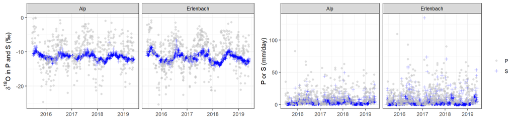

```r
# Create list object to store plot
plt <- list()

# Plot isotope data in precipitation and streamflow
plt[[1]] <- ggplot(isotopeData) +
  geom_point(aes(x = date,
                 y = delta_18O,
                 col = variable,
                 shape = variable),
             alpha = 0.5)+
  facet_grid(cols = vars(catchment))+
  scale_color_manual(name = "",
                     values=c("gray", "blue", NA, NA),
                     labels = c(expression("c"[P]), expression("c"[S]),NA, NA))+
  scale_shape_manual(name = "",
                     values=c(16, 3, NA, NA),
                     labels = c(expression("c"[P]), expression("c"[S]), NA, NA))+
  labs(x = "",
       y = expression(paste(delta^{18}, "O in P and S (‰)")),
       color = "") +
  theme_bw() +
  theme(legend.position = "none")

# Plot precipitation (P) and streamflow (S)
plt[[2]] <- ggplot(isotopeData) +
  geom_point(aes(x = date,
                 y = water_flux_mm,
                 col = variable,
                 shape = variable),
             alpha = 0.5)+
  facet_grid(cols = vars(catchment))+
  scale_color_manual(name = "",
                     values=c("gray", "blue", NA, NA),
                     labels = c("P", "S",NA, NA))+
  scale_shape_manual(name = "",
                     values=c(16, 3, NA, NA),
                     labels = c("P", "S", NA, NA))+
  labs(x = "", y = "P or S (mm/day)", color = "") +
  theme_bw() +
  theme(legend.position = "right")

# Arrange plots in to 2 rows and 2 columns
ggarrange(plt[[1]], plt[[2]], ncol = 2, nrow = 1)
```

## 3. Young water fraction estimation

Extracting data from ‘isotopeData’ for each catchment separately

```r
# Extract data
catchmentName <- unique(isotopeData$catchment)

# Extracted data as list
isotopeP <- list()
isotopeS <- list()

# Get isotope in precipitation (P) and streamflow (S) for the Alp & Erlenbach
for (i in 1:2){
  isotopeP[[i]] <- subset(isotopeData,
                          catchment == catchmentName[i] & variable == "precipitation")
  isotopeS[[i]] <- subset(isotopeData,
                          catchment == catchmentName[i] &  variable == "streamflow")
}
```

### 3.1. Traditional procedure

The procedure for finding the young water fraction and the transit time distribution in the traditional procedure is as follows:

- Step 1: Fit the sine-wave to observed isotope in precipitation, e.g., using the iteratively least squares (IRLS) regression approach. The sine-wave used for fitting has the following form :

  $$c_P(t) = a_P \cdot cos(2 \pi t) + b_P
  \cdot sin(2 \pi t) + k_P$$

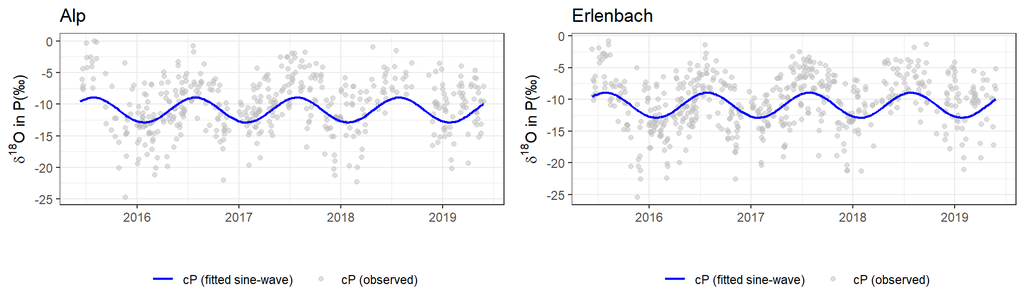

```r
# Create a list object to store results from the traditional procedure
traditionalProcedure <- list()
traditionalProcedure$fitSineP <- list()

# Loop over each catchment
for (i in 1:2){
  # Get date of observed in decimal
  t <- decimal_date(isotopeP[[i]]$date) - trunc(decimal_date(isotopeP[[i]]$date))

  # Fit to sine wave to observed isotope in P using IRLS method
  traditionalProcedure$fitSineP[[i]] <- IRLS(Y = isotopeP[[i]]$delta_18O,
                                             X = data.frame(cos = cos(2*pi*t), sin = sin(2*pi*t)),
                                             pweights = isotopeP[[i]]$water_flux_mm)
}

# Plot to see the fitted sine-wave to observed isotope composition in precipitation
for (i in 1:2){
 plt[[i]] <- ggplot()+
  geom_point(data = isotopeP[[i]],
             aes(x = date,
                 y = delta_18O,
                 color = "cP (observed)"),
             alpha = 0.5) +
  geom_line(aes(x = isotopeP[[i]]$date,
                y = as.numeric(traditionalProcedure$fitSineP[[i]]$fitted.values),
                color = "cP (fitted sine-wave)"),
            linewidth = 0.75) +
  scale_color_manual(values = c("cP (observed)" = "gray", "cP (fitted sine-wave)" = "blue"),
                     guide = guide_legend(override.aes = list(linetype = c("solid", "blank"),
                                                              shape = c(NA, 19)))) +
  labs(x = "",
       y = expression(paste(delta^{18}, "O in P(‰)")),
       title = catchmentName[i], color = "") +
  theme_bw() +
  theme(legend.position = "bottom")
}

# Arrange and display plots
ggarrange(plt[[1]], plt[[2]], ncol = 2, nrow = 1)
```

- Step 2: Fit the sine-wave to observed isotope in streamflow, e.g., using IRLS. The sine-wave used for fitting has the following form:

  $$c_S(t) = a_S \cdot cos(2 \pi t) + b_P
  \cdot sin(2 \pi t) + k_S$$

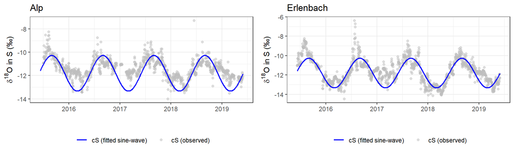

```r
# Loop over each catchment
for (i in 1:2){
  # Get date of observed in decimal
  t <- decimal_date(isotopeS[[i]]$date) - trunc(decimal_date(isotopeS[[i]]$date))

  # Fit to sine wave to observed isotope in P using IRLS method
  traditionalProcedure$fitSineS[[i]] <-
    IRLS(Y = isotopeS[[i]]$delta_18O,
         X = data.frame(cos = cos(2*pi*t), sin = sin(2*pi*t)),
         pweights = isotopeS[[i]]$water_flux_mm)
}

# Plot to see the fitted sine-wave to observed isotope in precipitation
for (i in 1:2){
  plt[[i]] <- ggplot()+
  geom_point(data = isotopeS[[i]],
             aes(x = date, y = delta_18O, color = "cS (observed)"),
             alpha = 0.5) +
  geom_line(aes(x = isotopeS[[i]]$date,
                y = as.numeric(traditionalProcedure$fitSineS[[i]]$fitted.values),
                color = "cS (fitted sine-wave)"),
            linewidth = 0.75) +
  scale_color_manual(values = c("cS (observed)" = "gray",
                                "cS (fitted sine-wave)" = "blue"),
                     guide = guide_legend(override.aes =
                                            list(linetype = c("solid", "blank"),
                                                 shape = c(NA, 19))))+
  labs(x = "",
       y = expression(paste(delta^{18}, "O in S (‰)")),
       title = catchmentName[i], color = "") +
  theme_bw() +
  theme(legend.position = "bottom")
}

# Arrange and display plots
ggarrange(plt[[1]], plt[[2]], ncol = 2, nrow = 1)
```

- Step 3: Infer the transit time (parameters of the gamma) distribution and Fyw

```r
for (icatchment in 1:2){
  # Coefficient of the sine-wave cP = aP*cos(2*pi*t) + aP*sin(2*pi*t) + kP
  traditionalProcedure$kP[icatchment] <- as.numeric(traditionalProcedure$fitSineP[[icatchment]]$coefficients[1])
  traditionalProcedure$aP[icatchment] <- as.numeric(traditionalProcedure$fitSineP[[icatchment]]$coefficients[2])
  traditionalProcedure$bP[icatchment] <- as.numeric(traditionalProcedure$fitSineP[[icatchment]]$coefficients[3])

  # Coefficient of the sine-wave cS = aS*cos(2*pi*t) + aS*sin(2*pi*t) + kS
  traditionalProcedure$kS[icatchment] <- as.numeric(traditionalProcedure$fitSineS[[icatchment]]$coefficients[1])
  traditionalProcedure$aS[icatchment] <- as.numeric(traditionalProcedure$fitSineS[[icatchment]]$coefficients[2])
  traditionalProcedure$bS[icatchment] <- as.numeric(traditionalProcedure$fitSineS[[icatchment]]$coefficients[3])

  # Find amplitudes AP and AS
  traditionalProcedure$AP[icatchment] <- sqrt(sum(traditionalProcedure$aP[icatchment]^2 +
                                                  traditionalProcedure$bP[icatchment]^2))
  traditionalProcedure$AS[icatchment] <- sqrt(sum(traditionalProcedure$aS[icatchment]^2 +
                                                  traditionalProcedure$bS[icatchment]^2))

  # Find phiS, phiP and the phase shift phiS - phiP
  phi <- findPhiPhaseShift(aP = traditionalProcedure$aP[icatchment],
                           bP = traditionalProcedure$bP[icatchment],
                           aS = traditionalProcedure$aS[icatchment],
                           bS = traditionalProcedure$bS[icatchment])

  traditionalProcedure$phiP[icatchment] <- phi$phiP
  traditionalProcedure$phiS[icatchment] <- phi$phiS
  traditionalProcedure$phiS_phiP[icatchment] <- phi$phiS_phiP

  # Find parameters of the gamma distribution (alpha, beta)
  alphaBeta <- findAlphaBetaMTT(phiS_phiP = traditionalProcedure$phiS_phiP[icatchment],
                                AS = traditionalProcedure$AS[icatchment],
                                AP = traditionalProcedure$AP[icatchment])

  traditionalProcedure$alpha[icatchment] <- alphaBeta$alpha
  traditionalProcedure$beta[icatchment] <- alphaBeta$beta

  # Find age threshold of young water fraction
  traditionalProcedure$tauyw[icatchment] <-  0.0949 +
    0.1065*traditionalProcedure$alpha[icatchment] -
    0.0126*traditionalProcedure$alpha[icatchment]^2

  # Young water fraction = AS/AP
  traditionalProcedure$ASAPratio[icatchment] <-  traditionalProcedure$AS[icatchment]/
                                                 traditionalProcedure$AP[icatchment]

  # Young water fraction from gamma distribution with found tauyw and gamma distribution
  traditionalProcedure$Fyw[icatchment] <- pgamma(q = traditionalProcedure$tauyw[icatchment],
                                                 shape = traditionalProcedure$alpha[icatchment],
                                                 scale = traditionalProcedure$beta[icatchment],
                                                 lower.tail = TRUE)
}

# Assembling the above results (step 3) into a table
source('R/summaryResult.R')
traditionalProcedure$summaryResult <- summaryResult(traditionalProcedure)

# Display the result
traditionalProcedure$summaryResult
```

```
##                   Alp   Erlenbach
## AP          2.1860709   1.9719208
## phiP        1.9465085   2.0165472
## kP        -10.5811545 -10.9208729
## AS          0.9712444   1.5297486
## phiS        2.6981767   2.6264287
## kS        -11.5071844 -11.8021790
## phiS_phiP   0.7516682   0.6098815
## alpha       0.5648813   0.8135154
## beta        0.6499960   0.1481750
## ASAPratio   0.4442877   0.7757657
## Fyw         0.4541171   0.7617801
```